# individual1.Rmd

Dana Thacker

3/15/2021

```r
library(readxl)
library(tidyverse)
```

```r
library(ggplot2)
defense <- read_excel('../ds202_lab4/cyclonesFootball2020.xlsx', sheet='Defensive')
offense <- read_excel('../ds202_lab4/cyclonesFootball2020.xlsx', sheet='Offensive')
biography <- read_excel('../ds202_lab4/cyclonesFootball2020.xlsx', sheet='Biography')
```

**Part One: Cleaning Data** Although the three Excel sheets are loaded into R, they are not useful before some cleaning. Manipulate the three imported data frames, so that in the cleaned dataset: *Problem 1* The player names and opponent names are factors.

```r
defense <- defense %>%
  mutate(Name = as.factor(Name),
         Opponent_Opponent = as.factor(Opponent_Opponent))

offense <- offense %>%
  mutate(Name = as.factor(Name),
         Opponent_Opponent = as.factor(Opponent_Opponent))

biography <- biography %>%
  mutate(Name = as.factor(Name))
```

*Problem 2* All offensive and defensive statistics are numerical. The Weight column in biography is also numeric. (Optional: Read ?across and learn to mutate multiple columns simultaneously using the across function in dplyr)

```r
defense <- defense %>%
  mutate(across(Tackles_Solo:Pass_PB, as.numeric))

offense <- offense %>%
  mutate(across(Receiving_REC:Passing_INT, as.numeric))
```

```r
biography <- biography %>%
  mutate(Weight = as.numeric(Weight))
```

*Problem 3* Change the Height column in biography into numeric. (Hint: Use a unit that works well)

```r
biography <- biography %>%
  separate(Height, c('Feet', 'Inches'), sep='-')

biography <- biography %>%
  mutate(Feet = as.numeric(Feet),
         Inches = as.numeric(Inches))
```

**Part 2: Tidying Data** *Problem 1* Reformat the offClean data frame into a tidy format using pivot_longer. The type of statistic (Receiving_REC for the number of receptions, Receiving_YDS for receiving yards, etc) is added as a new key column named stat.

```r
offClean <- offense %>%
  pivot_longer(Receiving_REC:Passing_INT, names_to = 'Type', values_to = 'Stat')
```

*Problem 2* Show on the distributions of the offensive statistics. The distribution of each offensive statistic should be shown in a separate facet. Explain the patterns you see.

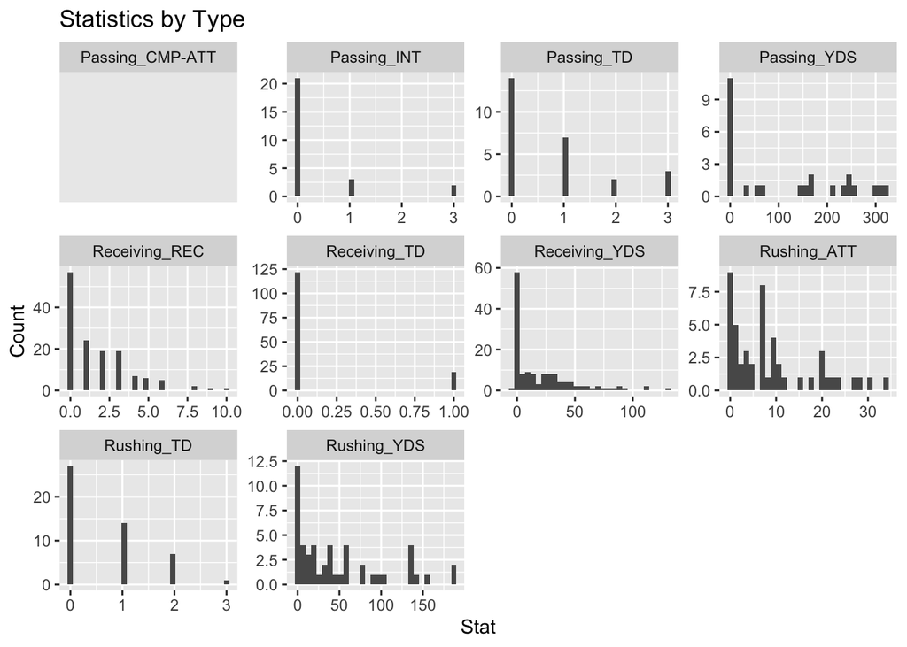

```r
ggplot(offClean, aes(x = Stat)) + geom_histogram() + facet_wrap(~ Type, scales = 'free') + xlab("Stat") + ylab("Count") + ggtitle("Statistics by Type")
```

*Problem 3* Did ISU have better offense against Oregon or Oklahoma? Answer this question by creating a scatterplot with the x- and y-axes being the receiving yards of the ISU players against these two opponents. A large number of receiving yards indicates good offense.

```r
offOreOkl <- offClean %>%
  filter(Opponent_Opponent %in% c("Oregon", "Oklahoma")) %>%
  group_by(Name) %>%
  filter(Type == "Receiving_YDS")

offOklahoma <- offOreOkl %>%
  filter(Opponent_Opponent %in% c("Oklahoma")) %>%
  group_by(Name) %>%
  summarise(Average = mean(Stat))

offOregon <- offOreOkl %>%
  filter(Opponent_Opponent %in% c("Oregon"))

offOreOklAvg <- offOreOkl %>%
  left_join(offOklahoma)
offOreOklPivoted <- offOreOklAvg %>%
  pivot_wider(names_from = 'Type', values_from = 'Stat') %>%
  filter(Opponent_Opponent %in% c("Oregon")) %>%
  rename(Oklahoma_Receiving_YDS = Average,
         Oregon_Receiving_YDS = Receiving_YDS) %>%
  mutate(Oklahoma_Receiving_YDS = as.numeric(Oklahoma_Receiving_YDS),
         Oregon_Receiving_YDS = as.numeric(Oregon_Receiving_YDS))
```

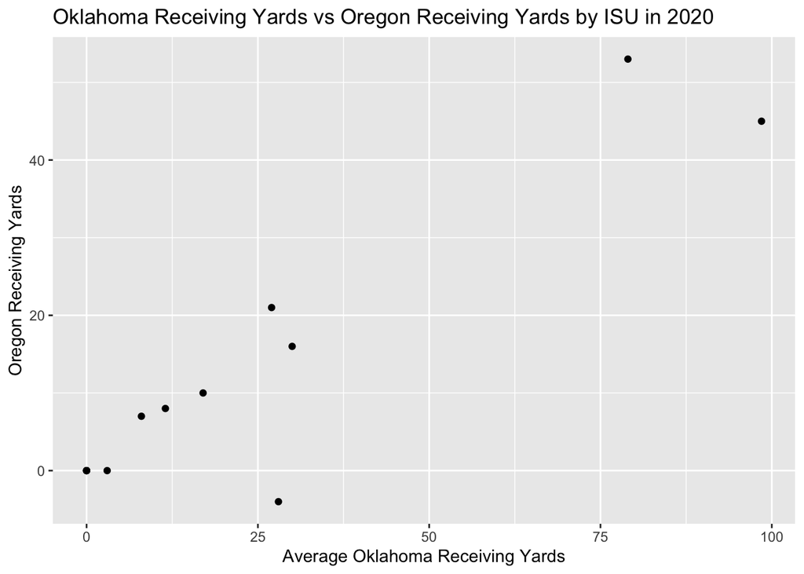

```r
ggplot(offOreOklPivoted, aes(x = Oklahoma_Receiving_YDS, y = Oregon_Receiving_YDS)) + geom_point() + xlab("Average Oklahoma Receiving Yards") + ylab("Oregon Receiving Yards") + ggtitle("Oklahoma Receiving Yards vs Oregon Receiving Yards by ISU in 2020")
```

*Problem 4* Separate the Hometown column into two columns, namely, the city and the state where the player comes from. Print the first few rows of these two columns. (Hint: look at the sep= argument of separate)

```r
biography <- biography %>%
  separate(Hometown, c('City', 'State'), sep = ', ')

head(biography, 4)
```

```
## # A tibble: 4 x 9
##   Name       Position    Feet Inches Weight Class     City     State Highschool
##   <fct>      <chr>      <dbl>  <dbl>  <dbl> <chr>     <chr>    <chr> <chr>
## 1 Akers, La… Wide Rece…     6      0    191 Redshirt… Cedar R… Iowa  Washington
## 2 Allen, Ch… Tight End      6      7    240 Redshirt… Nixa     Mo.   Nixa
## 3 Anderson,… Wide Rece…     6      5    208 Redshirt… Seffner  Fla.  Armwood
## 4 Antoine J… Defensive…     6      0    180 Freshman  Ft. Lau… Fla.  Cardinal G…
```

*Problem 5* How many players are there from each state?

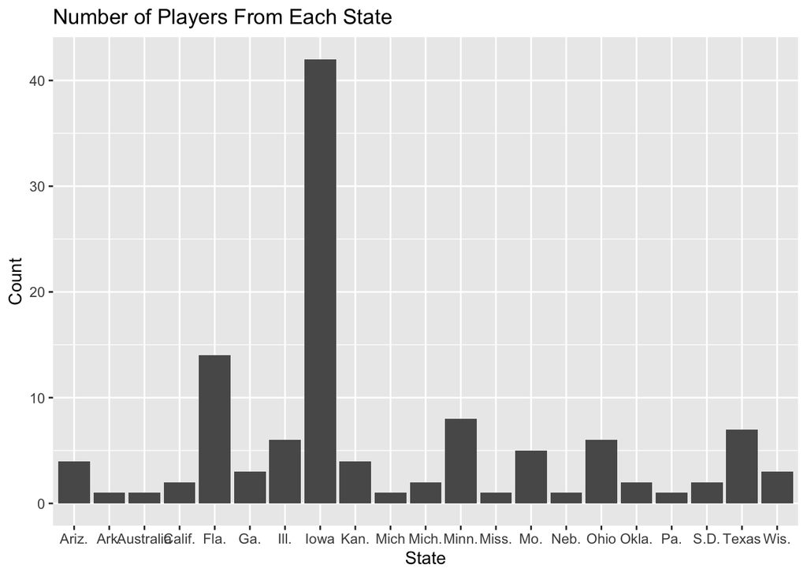

```r
ggplot(biography, aes(x = State)) + geom_bar() + xlab("State") + ylab("Count") + ggtitle("Number of Players From Each State")
```

**Part 3: Joining Data Frames** *Problem 1* Find which states do the ISU players (both defensive and offensive) come from. Create an appropriate numerical or graphical summary.

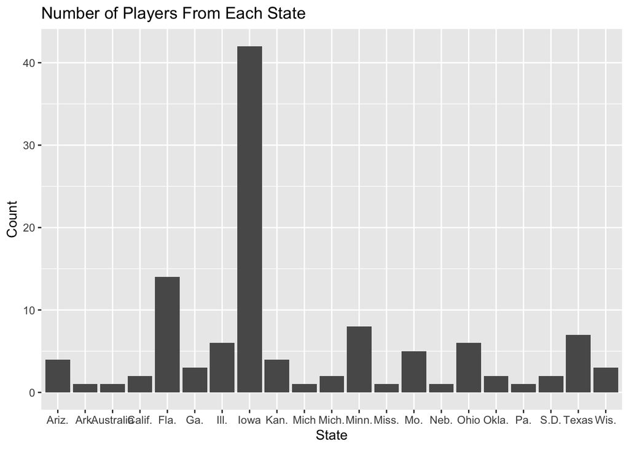

```r
ggplot(biography, aes(x = State)) + geom_bar() + xlab("State") + ylab("Count") + ggtitle("Number of Players From Each State")
```

*Problem 2* How does the performance of quarterback Brock Purdy relate to the performance of the ISU team?

```r
allTeam <- defense %>% full_join(offense, by = c("Name", "Opponent_Opponent"))

Purdy <- allTeam %>%
  filter(Name %in% c('Purdy, Brock')) %>%
  select(Name, Opponent_Opponent, Passing_YDS)

ReceivingYds <- offense %>%
  select(Name, Opponent_Opponent, Receiving_YDS)

Purdy_ReceivingYds <- Purdy %>% full_join(ReceivingYds)
Purdy_ReceivingYds2 <- Purdy_ReceivingYds %>%
  pivot_wider(names_from = 'Opponent_Opponent', values_from = 'Passing_YDS')
#dat <- offClean %>%
  #group_by(Name) %>%
  #summarise(____ = mean(_____, na.rm = TRUE))
```

*Problem 3* Which ISU player(s) made the biggest progress over the last year? Compare the player-level statistics (i.e. averages and totals for each player) using both the 2020 and the 2019 data here. Choose for yourself the player statistics to investigate.

```r
defense19 <- read_excel('../ds202_lab4/cyclonesFootball2019.xlsx', sheet='Defensive')
offense19 <- read_excel('../ds202_lab4/cyclonesFootball2019.xlsx', sheet='Offensive')

#Investigate Charlie Kolar
Charlie19 <- offense19 %>%
  filter(Name == 'Kolar, Charlie') %>%
  select(Name, Opponent_Opponent, Receiving_YDS) %>%
  mutate(Receiving_YDS = as.numeric(Receiving_YDS))
Charlie20 <- offense %>%
  filter(Name == 'Kolar, Charlie') %>%
  select(Name, Opponent_Opponent, Receiving_YDS)
Charlie19Rec <- mean(Charlie19$Receiving_YDS)
Charlie20Rec <- mean(Charlie20$Receiving_YDS)

#Investigating Chase Allen
Chase19 <- offense19 %>%
  filter(Name == 'Allen, Chase') %>%
  select(Name, Opponent_Opponent, Receiving_YDS) %>%
  mutate(Receiving_YDS = as.numeric(Receiving_YDS))
Chase20 <- offense %>%
  filter(Name == 'Allen, Chase') %>%
  select(Name, Opponent_Opponent, Receiving_YDS)
Chase19Rec <- mean(Chase19$Receiving_YDS)
Chase20Rec <- mean(Chase20$Receiving_YDS)

#Investigating Breece Hall
Breece19 <- offense19 %>%
  filter(Name == 'Hall, Breece') %>%
  select(Name, Opponent_Opponent, Rushing_YDS) %>%
  mutate(Rushing_YDS = as.numeric(Rushing_YDS))
Breece20 <- offense %>%
  filter(Name == 'Hall, Breece') %>%
  select(Name, Opponent_Opponent, Rushing_YDS)
Breece19Rec <- mean(Breece19$Rushing_YDS)
Breece20Rec <- mean(Breece20$Rushing_YDS)
```

I looked at the records of tight ends Chase Allen and Charlie Kolar, and running back Breece Hall. I compared Charlie and Chase’s recieving yards records and separately looked at Breece Hall’s record. I found that all of them performed better in the 2020 season than they did in 2019. Charlie added 0.11 yards to his season average and Chase added 8.61 yards to his season average. Breece hall increased his rushing yard average from 2019 to 2020 bt 56.25 yards to go from 74.75 yards as his 2019 season average to 131 yards in 2020.